# Unsupervised learning tools

Dramé Omar

# The motivation

The goal of this notebook is to be able to anticipate the position of an unknown or new player only using his statistics and skills. With that we could be able to see if some players should be playing in other position for example.

```r
library(leaflet)
library(rgdal)
library(stringr)
library(tidyverse)
library(GGally)
library(factoextra)
library(cluster)
library(mclust)
library(kernlab)
```

```r
library(igraph)
```

# The data set

We start by getting the raw data from this website : https://www.kaggle.com/datasets/vivovinco/20212022-football-player-stats. We have here data about the 2021-2022 football season. There is information about individual players in the 5 biggest Europeans competitions, Premier League England, Ligue 1 France, Bundesliga Germany, Serie A Italie and La Liga Spain. The season contains 38 or 36 games and most of the variables are for 90 minutes (per games).

```r
raw_data = read.csv(file = "FootballPlayers.csv",header = FALSE,sep = ',', fileEncoding="latin1")
```

We can look at the raw data to have an idea about the data set with the function glimpse, With dim we see that there are 143 variables mostly doubles and 2921 rows or players.

```r
glimpse(raw_data)
```

```
## Rows: 2,921
## Columns: 143
## $ V1   <int> 1, 2, 3, 4, 5, 6, 7, 8, 9, 10, 11, 12, 13, 14, 15, 16, 17, 18, 19…
## $ V2   <chr> "Andrés Andrade Cedeño", "Jacob Barrett Laursen", "George Bello",…
## $ V3   <chr> "PAN", "DEN", "USA", "SUI", "GER", "GER", "NED", "SUI", "GER", "T…
## $ V4   <chr> "DF", "DF", "DF", "DF", "MFFW", "DF", "DF", "DFFW", "FWMF", "FW",…
## $ V5   <chr> "Arminia", "Arminia", "Arminia", "Arminia", "Arminia", "Arminia",…
## $ V6   <chr> "Bundesliga", "Bundesliga", "Bundesliga", "Bundesliga", "Bundesli…
## $ V7   <int> 23, 27, 20, 28, 34, 23, 29, 26, 23, 18, 28, 34, 23, 23, 23, 24, 2…
## $ V8   <int> 1998, 1994, 2002, 1994, 1987, 1999, 1992, 1996, 1998, 2004, 1994,…
## $ V9   <int> 17, 24, 10, 27, 12, 4, 1, 7, 30, 5, 1, 25, 27, 22, 23, 19, 31, 33…
## $ V10  <dbl> 12, 20, 3, 26, 4, 1, 0, 2, 13, 1, 1, 14, 12, 13, 7, 7, 31, 30, 33…
## $ V11  <int> 1046, 1632, 434, 2183, 436, 131, 14, 283, 1364, 139, 90, 1420, 11…
## $ V12  <dbl> 11.6, 18.1, 4.8, 24.3, 4.8, 1.5, 0.2, 3.1, 15.2, 1.5, 1.0, 15.8, …
## $ V13  <dbl> 0.00, 0.11, 0.00, 0.00, 0.21, 0.00, 0.00, 0.00, 0.00, 0.00, 0.00,…
```

[output cut: 130 more lines]

```r
dim(raw_data)
```

```
## [1] 2921  143
```

## Notes about the data set

We’re going to define some variables and values.

The values for the position of a player are the following : - FW Forward player - MF Middle field player - DF Defensive player

Note that a player can have multiple positions.

The meaning of the variables :

- “matches_started” : Number of games where the player was in the initial 11 in the season
- “min_played” : Average time played per game
- “goals” : Average number of goals per game
- “shots” : Average number of attempted shots per game
- “passes” : Average number of attempted passes per game
- “good_passes” : Average number of successful shots per game
- “assists” : Average number of passes (of any kind) before another player scores per game
- “crosses” : Average number of attempted crosses per game
- “tackles” : Average number of attempted tackles per game
- “good_tackles” : Average number of successful tackles per game
- “interceptions” : Average number of ball interceptions per game
- “clearances” : Average number of ball clearances per game
- ” def_touches” : Average number of ball touches in the 1/3 defensive field per game
- “at_touches” : Average number of ball touches in the 1/3 offensive field per game
- “dribbles” : Average number of attempted dribbles per game
- “good_dribles” : Average number of successful dribbles per game
- “fouls_drawn” : Average number of fouls done to the player per game
- “areal_wins” : Average number of ball touches in the air against position
- “dribbles_goal” : Average number of dribbles that led to a goal per game
- “goal_action” : Average number of actions that led to a goal per game
- “shots_target” : Average number of shots on target per game

# Data preprocessing

## Feature engineering

There are a lot of variables taken into account, 143 seems too much so let’s try to keep the most useful ones. We don’t keep the variables that are judged non-relevant to the subject, we also delete variables that can be deduced from other ones by simple calculus like additions and multiplications.

We will define 2 data sets, the 1st one is just to have information that is categorical, like name and id. The second one is the one we will work with mostly. it will only contain 21 variables:

```r
players = raw_data %>% select(c(1,2,4,7,12))
colnames(players) = c("id","name","position","age","min_played")


players.df = raw_data %>% select(c(V10,V12,V13,V14,V24,V23,V37,V135,V82,V83,V101,V103,V107,V109,V112,V113,V133,V143,V78,V75,V15))
colnames(players.df) = c("matches_started","min_played","goals","shots","passes","good_passes","assists","crosses","tackles","good_tackles","interceptions","clearances","def_touches","at_touches","dribbles","good_dribles","fouls_drawn","areal_wins","dribbles_goal","goal_action","shots_target")

dim(players.df)
```

```
## [1] 2921   21
```

Then if we work with the current data, knowing that all of the variables are per game except for matches_started, we need to get rid of the player that did not play a lot because this will only bring noise. We don’t take into account players that have played less than 10 min per game in the season. With this operation we lose 1290 rows! Which means a lot of rows are noise knowing that 10 min per game really isn’t a lot.

```r
players  = players  %>% filter( min_played > 10)
players.df  = players.df  %>% filter( min_played > 10)
```

## Missing values

With the current data frame, we don’t have any missing values, note that there are some in the raw data.

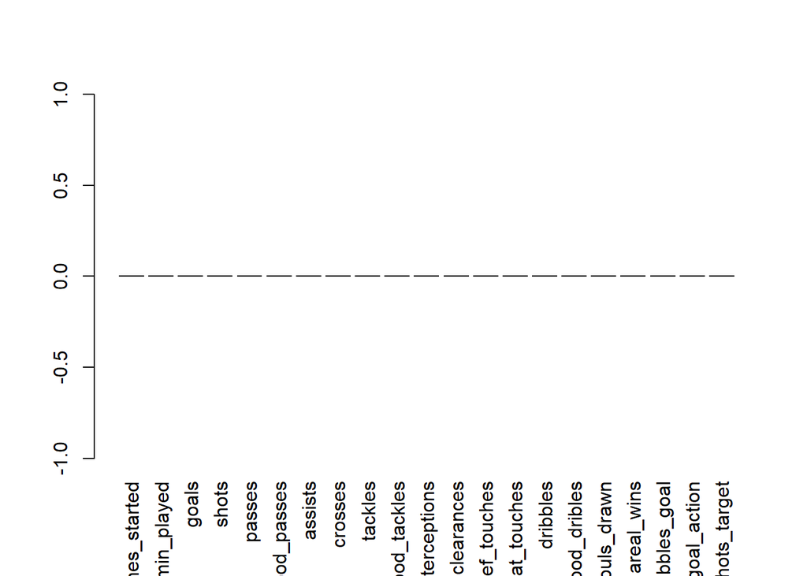

```r
barplot(colMeans(is.na(players.df)), las=3)
```

```r
dim(players.df)
```

```
## [1] 1631   21
```

## Outliers

There is a high variability with certain variables, but we can work with it since the data set is very large, the data seems realistic even though there are a few relatively high values remaining. It seems like the data set is quite clean after the feature engineering because there are clearly extreme values in the raw data set. Once again, I don’t see the need to add something here.

```r
summary(players.df)
```

```
##  matches_started   min_played        goals            shots
##  Min.   : 6.00   Min.   :10.10   Min.   :0.0000   Min.   :0.000
##  1st Qu.:16.00   1st Qu.:15.70   1st Qu.:0.0000   1st Qu.:0.445
##  Median :22.00   Median :21.10   Median :0.0700   Median :0.870
##  Mean   :22.25   Mean   :21.84   Mean   :0.1272   Mean   :1.148
##  3rd Qu.:29.00   3rd Qu.:27.75   3rd Qu.:0.1800   3rd Qu.:1.760
##  Max.   :38.00   Max.   :38.00   Max.   :1.0700   Max.   :4.800
##      passes       good_passes       assists           crosses
##  Min.   :11.40   Min.   : 7.99   Min.   :0.00000   Min.   :0.000
##  1st Qu.:33.25   1st Qu.:24.60   1st Qu.:0.00000   1st Qu.:0.185
##  Median :43.10   Median :33.90   Median :0.06000   Median :0.750
##  Mean   :44.33   Mean   :35.36   Mean   :0.08863   Mean   :1.083
##  3rd Qu.:54.60   3rd Qu.:44.45   3rd Qu.:0.14000   3rd Qu.:1.790
##  Max.   :99.60   Max.   :91.40   Max.   :0.83000   Max.   :6.820
##     tackles       good_tackles   interceptions     clearances
##  Min.   :0.000   Min.   :0.000   Min.   :0.000   Min.   :0.000
##  1st Qu.:1.060   1st Qu.:0.620   1st Qu.:0.765   1st Qu.:0.560
##  Median :1.640   Median :0.980   Median :1.450   Median :1.220
##  Mean   :1.647   Mean   :1.008   Mean   :1.419   Mean   :1.750
##  3rd Qu.:2.250   3rd Qu.:1.370   3rd Qu.:2.000   3rd Qu.:2.605
##  Max.   :4.430   Max.   :3.390   Max.   :5.220   Max.   :7.970
##   def_touches       at_touches        dribbles       good_dribles
##  Min.   : 1.250   Min.   : 0.000   Min.   :0.0000   Min.   :0.000
##  1st Qu.: 7.555   1st Qu.: 5.525   1st Qu.:0.2600   1st Qu.:0.450
##  Median :16.400   Median :14.800   Median :0.6400   Median :1.170
##  Mean   :18.152   Mean   :13.900   Mean   :0.7819   Mean   :1.452
##  3rd Qu.:27.400   3rd Qu.:20.400   3rd Qu.:1.1300   3rd Qu.:2.120
##  Max.   :54.700   Max.   :47.000   Max.   :5.1300   Max.   :8.050
##   fouls_drawn      areal_wins     dribbles_goal      goal_action
##  Min.   :0.000   Min.   :  0.00   Min.   :0.00000   Min.   :0.0000
##  1st Qu.:0.630   1st Qu.: 34.90   1st Qu.:0.00000   1st Qu.:0.0600
##  Median :1.120   Median : 46.80   Median :0.00000   Median :0.1600
##  Mean   :1.212   Mean   : 44.53   Mean   :0.01173   Mean   :0.2039
##  3rd Qu.:1.670   3rd Qu.: 58.30   3rd Qu.:0.00000   3rd Qu.:0.3000
##  Max.   :4.790   Max.   :100.00   Max.   :0.30000   Max.   :1.1300
##   shots_target
##  Min.   :0.0000
##  1st Qu.:0.0900
##  Median :0.2400
##  Mean   :0.3784
##  3rd Qu.:0.5800
##  Max.   :2.3500
```

## Visualization

Let’s take a look at the data set, it has 1631 lines, or players and 21 variables. We can take a quick look with a general box plot and another one with scale values.

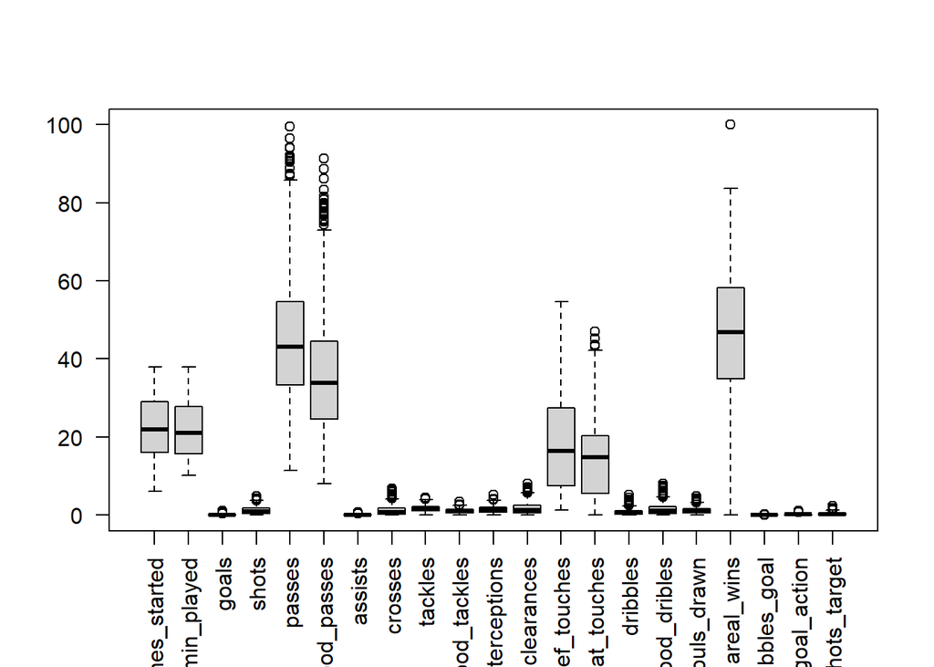

```r
boxplot(players.df, las = 2)
```

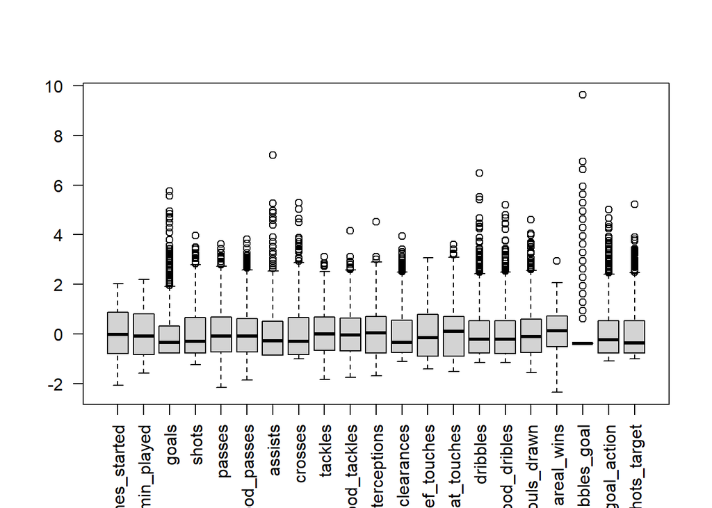

```r
boxplot(scale(players.df), las = 2)
```

If we take a look at the correlations between variables, some are highly or totally correlated (positively). This is the case for 1 the number of matches started, and the number of minutes played, 2 The passes and good passes,3 the shots, goals and shots on target, 4 tackles and good tackles and on and on… These correlations are logical and indicate that the data set seems realistic. Obviously, the player who has the most tackles passes and dribbles are going to be those who have respectively the best tackles, good passes and good dribbles. We can note 2 negative high correlations that are interesting, the number of defensive touches with the number of shots and the number of attacking touches, this is a manifestation of the position of the players.

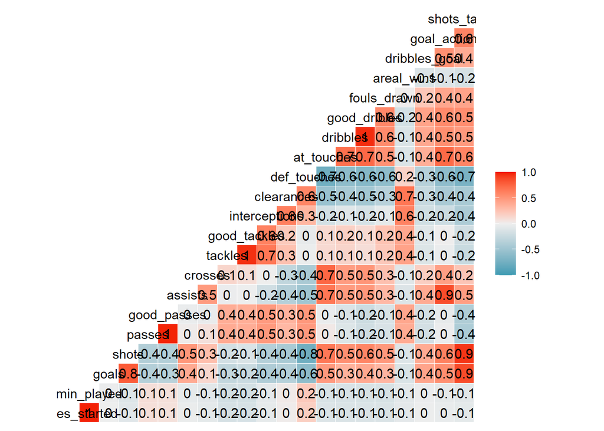

```r
ggcorr(scale(players.df),label = T)
```

# Principal Component Analysis

We do the PCA analysis by scaling the data, in order to get the contribution of every variable fairly. X is going to be our scale data in the rest of the notebook.

```r
X = scale (players.df)
pca = prcomp(X)
pca
```

```
## Standard deviations (1, .., p=21):
##  [1] 2.77670108 1.96760570 1.45711629 1.21636825 1.15998097 0.92063179
##  [7] 0.89585322 0.84560603 0.72010993 0.67118041 0.56195018 0.47556321
## [13] 0.41274063 0.36237600 0.32635481 0.22321176 0.21686794 0.19885741
## [19] 0.16781722 0.11233580 0.09299523
##
## Rotation (n x k) = (21 x 21):
##                         PC1         PC2           PC3         PC4         PC5
## matches_started  0.04681871  0.12279297  0.5822443390 -0.17301037  0.33502141
## min_played       0.05360820  0.13052555  0.5813291797 -0.16799538  0.32766290
## goals           -0.26267147  0.08984849  0.0309282627 -0.37608391 -0.17794620
## shots           -0.30786335  0.01296225 -0.0185339199 -0.30292762 -0.08215111
## passes           0.15209474 -0.31205595  0.2961467356  0.15705412 -0.30133484
## good_passes      0.15930553 -0.29894214  0.2775730423  0.10219405 -0.31279780
## assists         -0.23978966 -0.12465321  0.2011137234  0.10204159 -0.26819846
## crosses         -0.17894877 -0.18846190  0.1176398367  0.30990953  0.01820253
## tackles          0.06402405 -0.42645151 -0.1008548572 -0.05359459  0.27977958
## good_tackles     0.05175839 -0.41671819 -0.0981354338 -0.06520443  0.28768267
## interceptions    0.17276040 -0.34958471 -0.0220650124 -0.19018944  0.06834208
## clearances       0.24209635 -0.12862939 -0.0344321507 -0.37809817 -0.14632558
## def_touches      0.31127289  0.04094706  0.1302047510  0.07553056 -0.15495827
## at_touches      -0.29455265 -0.19925746  0.1114607313  0.13896072 -0.04475379
## dribbles        -0.26436275 -0.18624099  0.0151109912  0.11003047  0.19237481
## good_dribles    -0.28533252 -0.15552417  0.0005827159  0.09886180  0.19537508
## fouls_drawn     -0.21086030 -0.17116207 -0.0764373998 -0.08371223  0.26213612
## areal_wins       0.12055225 -0.28142436 -0.0292787286 -0.46607494 -0.14497745
## dribbles_goal   -0.19199235 -0.01126594  0.0988880342 -0.08173188 -0.15559876
## goal_action     -0.27635788 -0.12446139  0.1873333248  0.01095989 -0.25792152
## shots_target    -0.30117498  0.05661520 -0.0077209035 -0.32076679 -0.11088120
##                          PC6          PC7         PC8          PC9
## matches_started -0.008306121  0.045836280  0.03902752 -0.009327314
## min_played      -0.001985183  0.037642264  0.01826665 -0.001606017
## goals           -0.146197583 -0.104873888  0.02165769  0.300371132
## shots           -0.201446483 -0.015016655 -0.07008814  0.116449080
## passes          -0.196067342 -0.219777097 -0.14777748  0.091177928
## good_passes     -0.197181032 -0.318623560 -0.16216702  0.070636156
## assists          0.073913208  0.171272602  0.35800886 -0.396502820
## crosses         -0.020627758  0.636431279 -0.11413980  0.196535494
## tackles         -0.031915681 -0.054197792  0.32882386  0.198220393
## good_tackles    -0.062489827 -0.157641426  0.35720191  0.186660959
```

[output cut: 62 more lines]

```
## assists         -0.005571071  0.009402637  2.984647e-03  0.003625913
## crosses         -0.037943898  0.045415138  1.797761e-02  0.060240351
## tackles         -0.677461027 -0.038332652 -9.248897e-05  0.014052816
## good_tackles     0.646069915  0.041977802  8.404102e-03  0.001810778
## interceptions    0.053545168 -0.007981701  6.735712e-03  0.011692359
## clearances       0.004928752  0.002406344  1.522284e-03 -0.033440864
## def_touches      0.138039723 -0.130262297 -3.276697e-02  0.123242447
## at_touches       0.256224754 -0.225885421 -2.102237e-02  0.109761653
## dribbles        -0.065433715 -0.619921569 -1.771429e-02  0.028405975
## good_dribles     0.017990592  0.710319013  1.174213e-02 -0.066603375
## fouls_drawn     -0.002401505 -0.022477150  1.532920e-03 -0.003363247
## areal_wins       0.042031495 -0.015613898 -4.564836e-03  0.016363998
## dribbles_goal    0.007877503 -0.016349832 -6.519278e-03 -0.008826053
## goal_action     -0.022738594  0.020775684  1.523061e-02  0.007530311
## shots_target     0.072315225 -0.097209481 -1.310341e-02 -0.023353375
```

PCA needs a few components to describe a big chunk of the data set. With the first 4 variables we have 72.2% of the initial information, with 6 variables we have more than 80% of the data. To get an important share of the information we’re going to analyze the 6 first principal components. We reduce the dimension from 21 to 6 while keeping more than 80% of the data with the PCA.

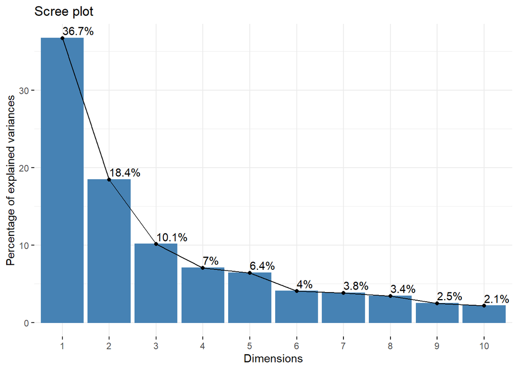

```r
fviz_screeplot(pca, addlabels = TRUE)
```

The 1st PC clearly describes an offensive player (with negative values), it gives importance to all the offensive qualities of the players like dribbles, attacking touches and goals. The defensive variables have a positive contribution to this PC. If we take a look at the five 5 players with this PC we find “Kylian Mbappé” “Vinicius Júnior” “Ousmane Dembélé” “Mohamed Salah” “Luis Muriel”. 3 of them are in the top 10 ranking of the balon d’or for that season and all of them are recognized as being world class offensive players.

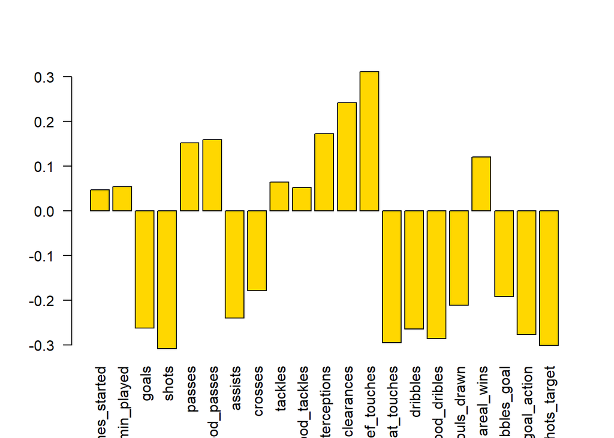

```r
barplot(pca$rotation[,1], las=2, col="gold")
```

```r
players$name[order(pca$x[,1])][1:10]
```

```
##  [1] "Kylian Mbappé"     "Vinicius Júnior"   "Ousmane Dembélé"
##  [4] "Mohamed Salah"     "Luis Muriel"       "Rafael Leão"
##  [7] "Neymar"            "Lionel Messi"      "Arnaut Groeneveld"
## [10] "Karim Benzema"
```

```r
players$position[order(pca$x[,1])][1:10]
```

```
##  [1] "FW"   "FW"   "FW"   "FW"   "FW"   "FW"   "FWMF" "FWMF" "FW"   "FW"
```

The 50 last players for that pc are all defenders!

```r
players$position[order(pca$x[,1])][(length(players$position)-49):length(players$position)]
```

```
##  [1] "DF" "DF" "DF" "DF" "DF" "DF" "DF" "DF" "DF" "DF" "DF" "DF" "DF" "DF" "DF"
## [16] "DF" "DF" "DF" "DF" "DF" "DF" "DF" "DF" "DF" "DF" "DF" "DF" "DF" "DF" "DF"
## [31] "DF" "DF" "DF" "DF" "DF" "DF" "DF" "DF" "DF" "DF" "DF" "DF" "DF" "DF" "DF"
## [46] "DF" "DF" "DF" "DF" "DF"
```

The second PC gives importance (with negative values) to all types of qualities a player can have like tackles, passes, interceptions… This PC would be something like the most useful or complete player to a team. By taking a look at the 20 best players for that PC we see there is no one position that is present in a significantly large amount between defenders and midfielders. There basically no or very few forward players or goalkeepers in the first positions of that PC.

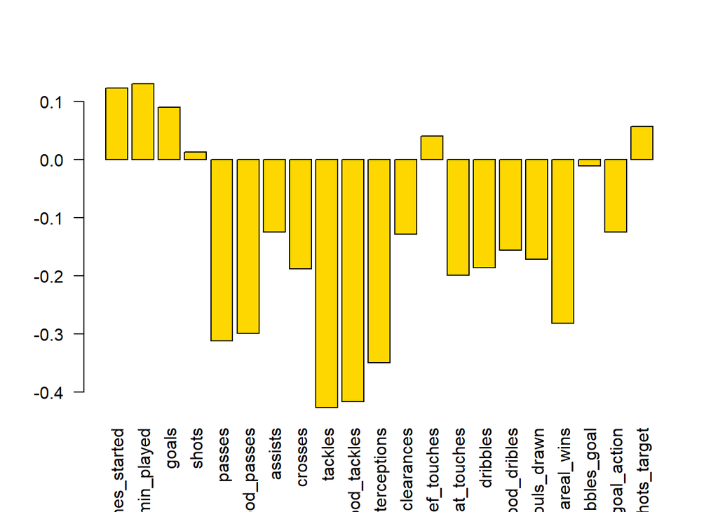

```r
barplot(pca$rotation[,2], las=2, col="gold")
```

```r
players$name[order(pca$x[,2])][1:20]
```

```
##  [1] "Thiago Alcántara"       "Jimmy Cabot"            "Ousmane Dembélé"
##  [4] "Ricardo Pereira"        "Bruno Guimarães"        "Maximilian Mittelstädt"
##  [7] "Marco Verratti"         "Alphonso Davies"        "Eduardo Camavinga"
## [10] "Danilo Soares"          "Bruno Guimarães"        "Dani Alves"
## [13] "Ismaël Bennacer"        "João Cancelo"           "Rafinha"
## [16] "Youcef Atal"            "Jean Onana"             "Ruben Aguilar"
## [19] "Exequiel Palacios"      "Malo Gusto"
```

```r
players$position[order(pca$x[,2])][1:20]
```

```
##  [1] "MF"   "DF"   "FW"   "DF"   "MF"   "DFFW" "MF"   "DF"   "MF"   "DF"
## [11] "MF"   "DF"   "MF"   "DF"   "MFFW" "DF"   "MF"   "DF"   "MF"   "DF"
```

The third PC doesn’t highlight a particular skill, it only gives information for the most used players. The most used being Kylian Mbappe which is not a surprise since he is very young, he picked up only very short injuries and started 34 out of 38 games in the season.

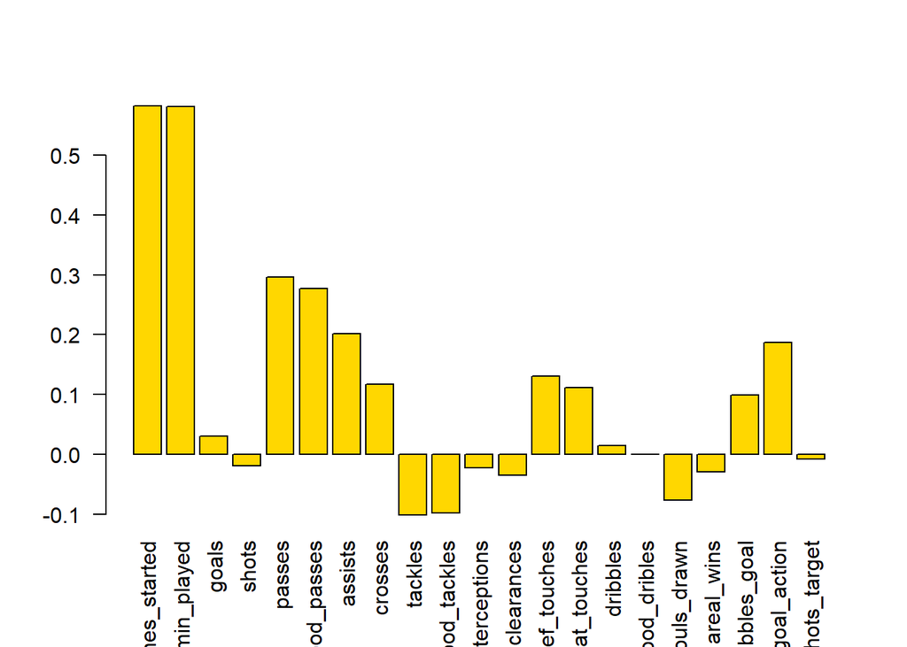

```r
barplot(pca$rotation[,3], las=2, col="gold")
```

```r
players$name[order(pca$x[,3])][(length(players$name)-9):length(players$name)]
```

```
##  [1] "Cristiano Biraghi"      "Antonio Candreva"       "Joshua Kimmich"
##  [4] "Benjamin Bourigeaud"    "Andrew Robertson"       "Lionel Messi"
##  [7] "Jordi Alba"             "Trent Alexander-Arnold" "João Cancelo"
## [10] "Kylian Mbappé"
```

```r
players$position[order(pca$x[,3])][(length(players$position)-9):length(players$position)]
```

```
##  [1] "DF"   "MFFW" "MF"   "FWMF" "DF"   "FWMF" "DF"   "DF"   "DF"   "FW"
```

The fourth PC talks about pure forward striker skills, with big emphasis on skills like goals, shots on target and areal wins. Out of the 10 best players for that PC 9 are strikers. It gives importance to the physical ability (implicitly with areal wins) of a player, that’s why only tall people are present in this list.

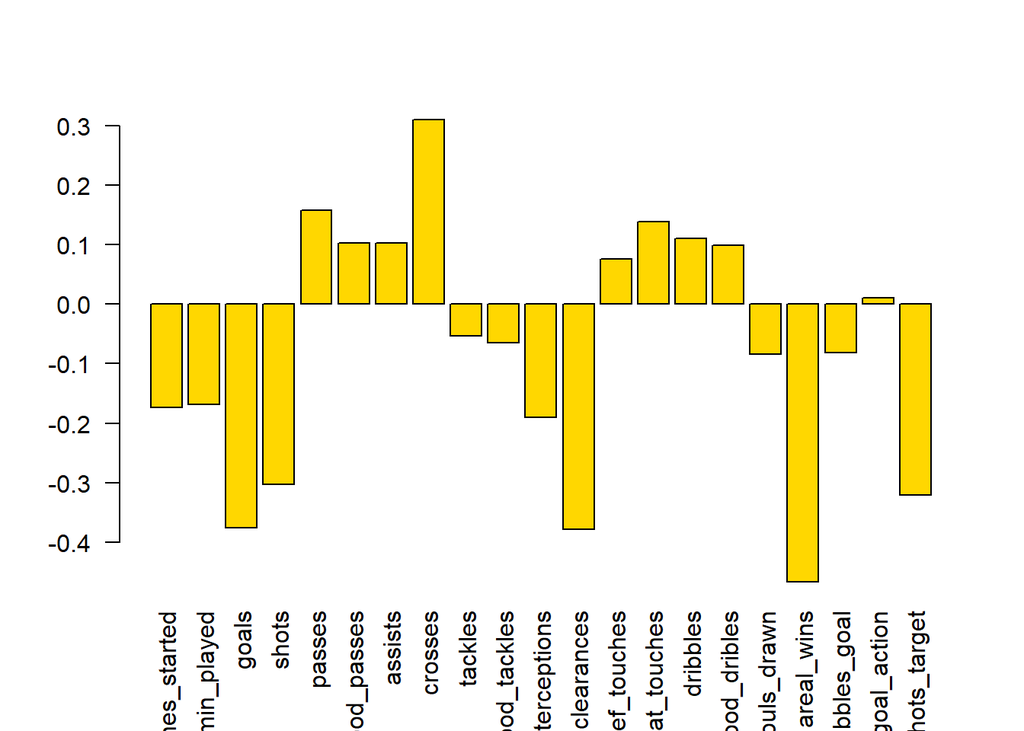

```r
barplot(pca$rotation[,4], las=2, col="gold")
```

```r
players$name[order(pca$x[,4])][1:10]
```

```
##  [1] "Robert Lewandowski" "Patrik Schick"      "Anthony Modeste"
##  [4] "Erling Haaland"     "Lautaro Martínez"   "Moussa Dembélé"
##  [7] "Gianluca Scamacca"  "Ciro Immobile"      "Boubakar Kouyaté"
## [10] "Bamba Dieng"
```

```r
players$position[order(pca$x[,4])][1:10]
```

```
##  [1] "FW"   "FW"   "FW"   "FW"   "FW"   "FW"   "FW"   "FW"   "DF"   "FWMF"
```

The fifth and sixth are harder to explain but it seems like the 5th describes players that have great passing skills and the 6th players that create goal action by dribbling.

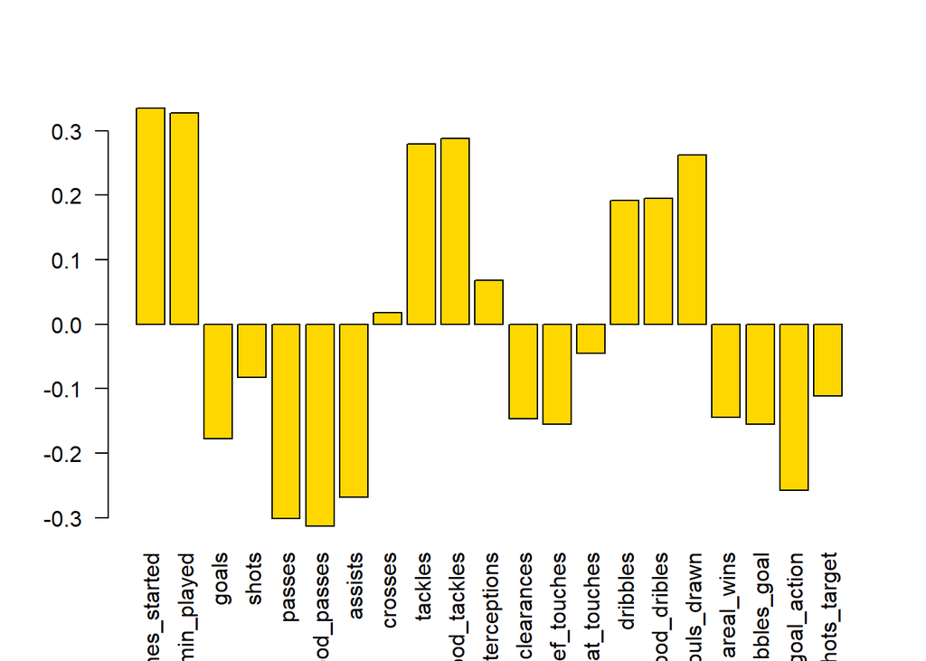

```r
barplot(pca$rotation[,5], las=2, col="gold")
```

```r
players$name[order(pca$x[,5])][1:10]
```

```
##  [1] "Oleksandr Zinchenko" "Lionel Messi"        "Zlatan Ibrahimovi?"
##  [4] "Karim Benzema"       "Erling Haaland"      "Loïc Bade"
##  [7] "Nathan Aké"          "John Stones"         "Dan-Axel Zagadou"
## [10] "Kylian Mbappé"
```

```r
players$position[order(pca$x[,5])][1:10]
```

```
##  [1] "DF"   "FWMF" "FW"   "FW"   "FW"   "DF"   "DF"   "DF"   "DF"   "FW"
```

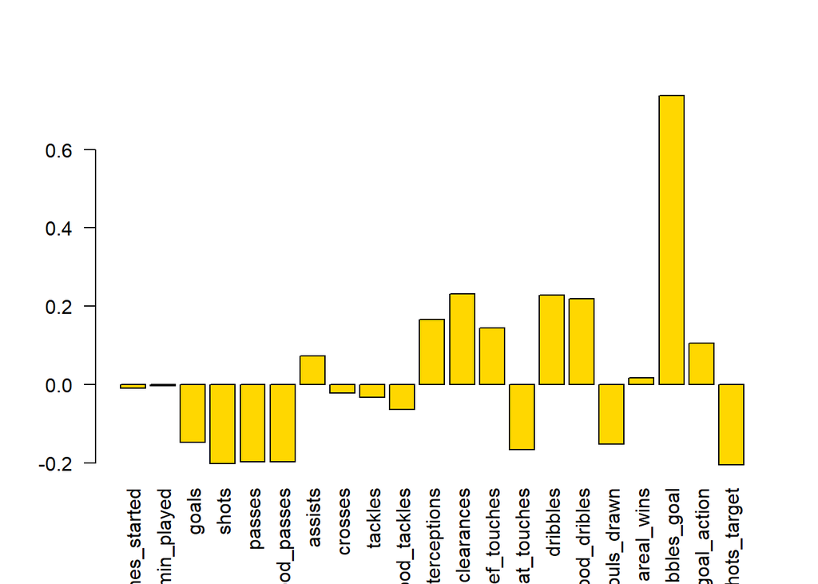

```r
barplot(pca$rotation[,6], las=2, col="gold")
```

```r
players$name[order(pca$x[,6])][1:10]
```

```
##  [1] "Sehrou Guirassy"           "Toni Kroos"
##  [3] "Zlatan Ibrahimovi?"        "Lautaro Martínez"
##  [5] "Paulo Dybala"              "Rodri"
##  [7] "Riyad Mahrez"              "Pierre-Emerick Aubameyang"
##  [9] "Robert Lewandowski"        "Du\u009aan Vlahovi?"
```

```r
players$position[order(pca$x[,6])][1:10]
```

```
##  [1] "FW"   "MF"   "FW"   "FW"   "FWMF" "MF"   "FW"   "FW"   "FW"   "FW"
```

With the next plot we have the player with the best offensives skill to the right and the best general skills to the top, the pc3 give the information on how much was the player used. We can note that at the bottom left there is a cluster of goalkeepers they “don’t have” any offensive skill nor general skills. The 1st point is obvious but the second one is less obvious, but we can explain it because in the data frame no variables describe goalkeeper abilities. It is difficult to give an interpretation for the use of a player since a player can play or not because of issues unrelated to his performances.

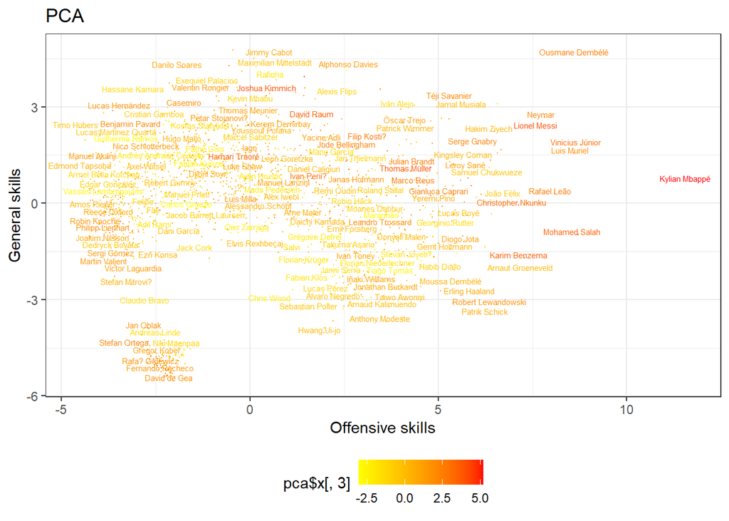

```r
data.frame(z1=-pca$x[,1],z2=-pca$x[,2]) %>%
  ggplot(aes(z1,z2,label=players$name,color=pca$x[,3])) + geom_point(size=0) +
  labs(title="PCA", x="Offensive skills", y="General skills")+theme_bw() + scale_color_gradient(low="yellow", high="red")+theme(legend.position="bottom") + geom_text(size=2, hjust=0.6, vjust=0, check_overlap = TRUE)
```

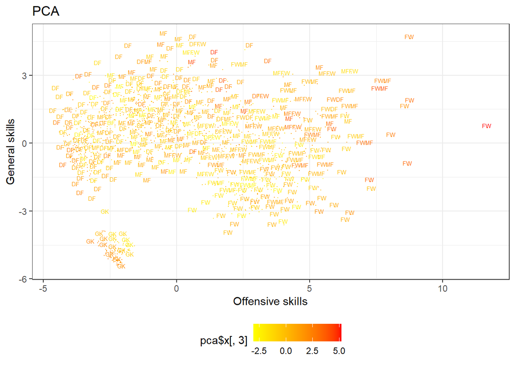

```r
data.frame(z1=-pca$x[,1],z2=-pca$x[,2]) %>%
  ggplot(aes(z1,z2,label=players$position,color=pca$x[,3])) + geom_point(size=0) +
  labs(title="PCA", x="Offensive skills", y="General skills")+theme_bw() + scale_color_gradient(low="yellow", high="red")+theme(legend.position="bottom") + geom_text(size=2, hjust=0.6, vjust=0, check_overlap = TRUE)
```

# Factor Analysis

## 4 factors

Once again, we’re going to use scaled data. We’re going to choose 4 factors, this is because we can divide players by basic positions :

- Goal keeper
- Defensive player
- Middle field player
- Offensive player

With the 4 factors we see that 67.5% of the data is considered, so we drop 17 variables but still get close to 70% of the information.

```r
X_fa_an <- factanal(X, factors = 4, rotation="none", scores="regression",scale = T)
# Contribution des facteurs aux variables
X_fa_an$loadings
```

```
##
## Loadings:
##                 Factor1 Factor2 Factor3 Factor4
## matches_started         -0.186   0.940   0.245
## min_played              -0.193   0.951   0.230
## goals            0.593  -0.382  -0.113
## shots            0.735  -0.322  -0.212   0.133
## passes                   0.821   0.366  -0.432
## good_passes              0.805   0.357  -0.441
## assists          0.716
## crosses          0.612   0.129
## tackles                  0.824  -0.147   0.542
## good_tackles             0.792  -0.140   0.516
## interceptions   -0.258   0.681           0.186
## clearances      -0.545   0.345   0.109
## def_touches     -0.718   0.265   0.368  -0.353
## at_touches       0.927          -0.143
## dribbles         0.713          -0.193   0.200
## good_dribles     0.739          -0.220   0.221
## fouls_drawn      0.539          -0.213   0.278
## areal_wins      -0.137   0.496
## dribbles_goal    0.443  -0.169
## goal_action      0.801
## shots_target     0.694  -0.379  -0.188   0.104
##
##                Factor1 Factor2 Factor3 Factor4
## SS loadings      6.204   4.053   2.502   1.426
## Proportion Var   0.295   0.193   0.119   0.068
## Cumulative Var   0.295   0.488   0.608   0.675
```

We see that here, the factor analysis gives very similar result compared to the PCA, except for the 4th Factor, let’s take a look at each of the four factors and at the 4 first pc. We see that for the 3 first the similarity is huge in the contribution of the key variables so we can give the same interpretation given for the PCA. We have Factor 1 that highlights offensive skill, Factor 2 that highlights general skills and the third one that gives an emphasis on how much was the player used.

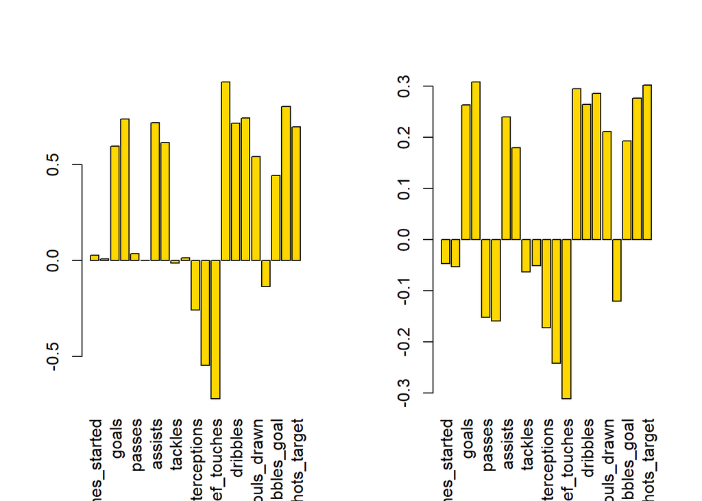

```r
par(mfrow=c(1,2))
barplot(X_fa_an$loadings[,1], las=3, col="gold")
barplot(-pca$rotation[,1], las=3, col="gold")
```

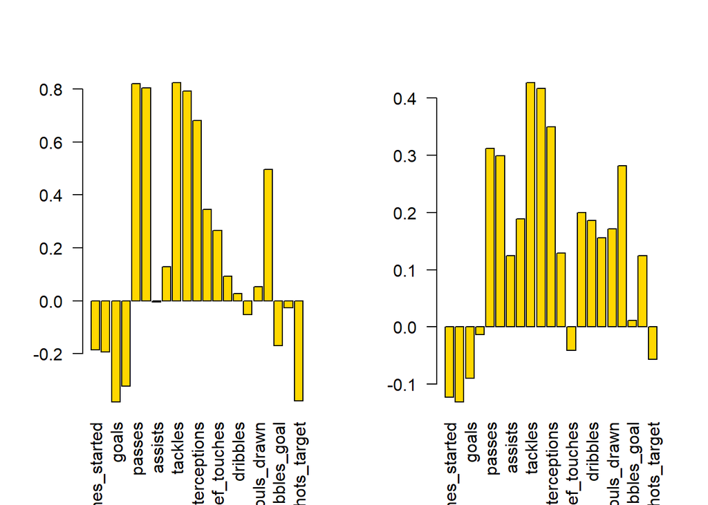

```r
barplot(X_fa_an$loadings[,2], las=2, col="gold")
barplot(-pca$rotation[,2], las=2, col="gold")
```

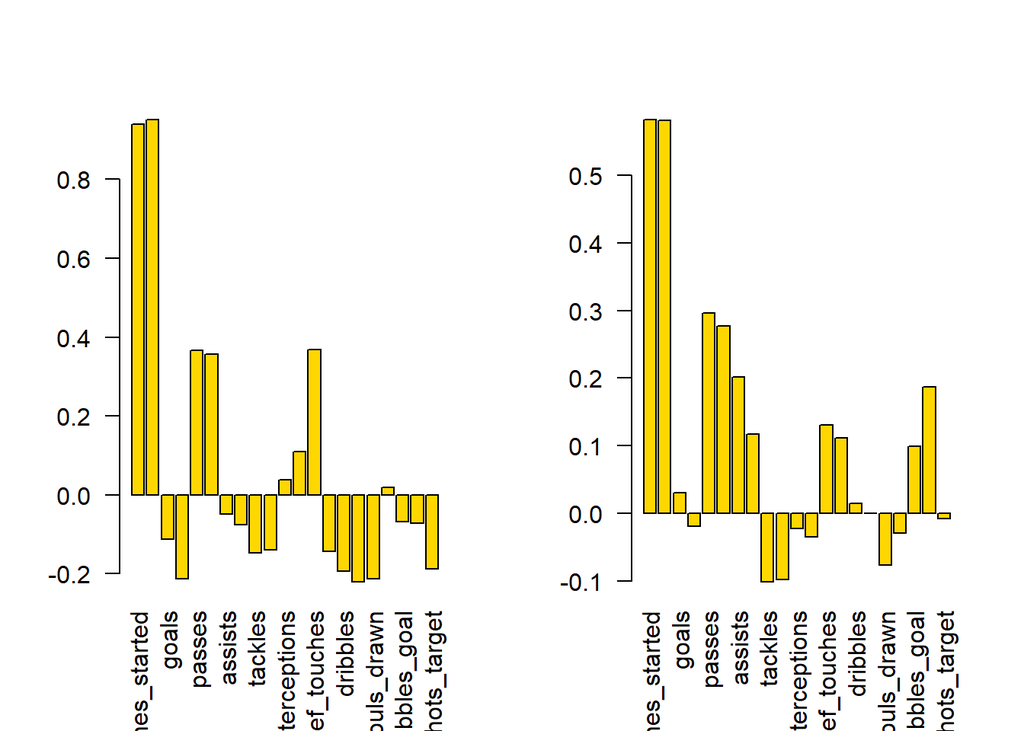

```r
barplot(X_fa_an$loadings[,3], las=2, col="gold")
barplot(pca$rotation[,3], las=2, col="gold")
```

The pc4 and the factor 4 are clearly different while PC4 gives importance to striking and physical abilities, the factor 4 give positive importance to tackles while giving a negative importance to defensive touches and passes. We really don’t get any information on positions with the 4th factor.

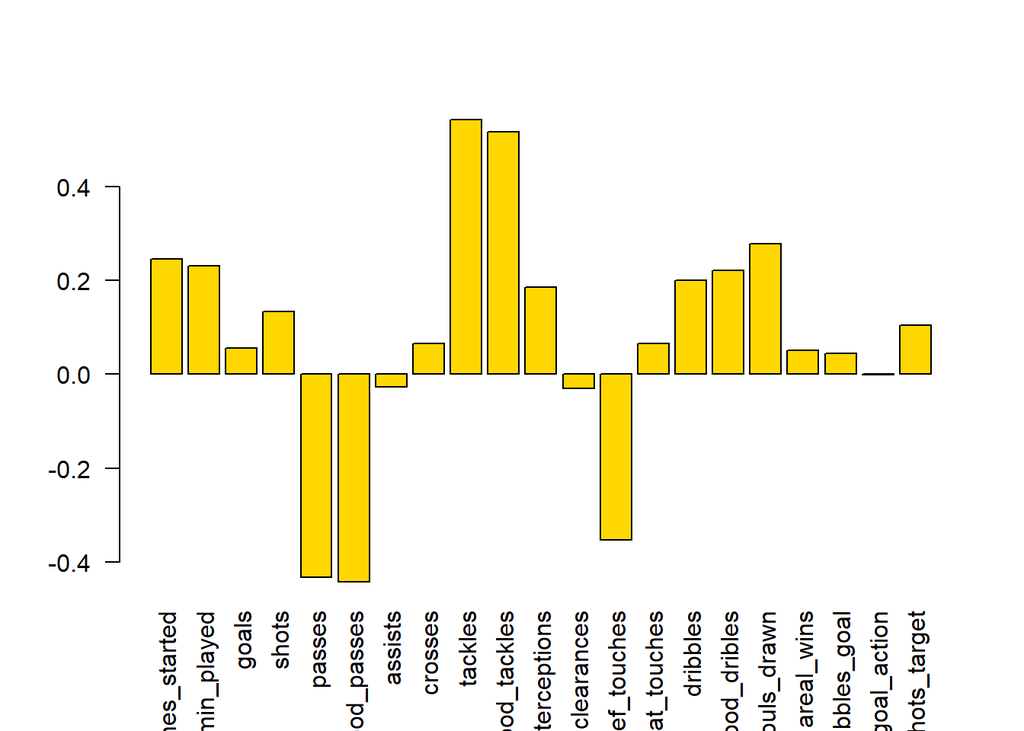

```r
barplot(X_fa_an$loadings[,4], las=2, col="gold")
```

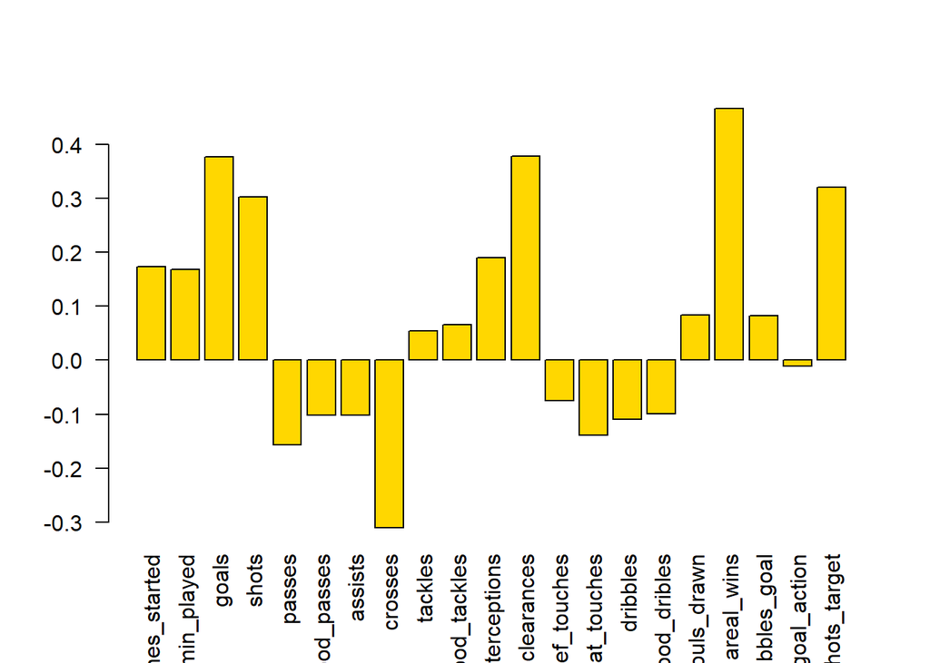

```r
barplot(-pca$rotation[,4], las=2, col="gold")
```

## 3 Factors

Since the 4th factor doesn’t seem very helpful, we can also try with 3 factors but now we only have 57% of the data. The first factor is always very similar to the pc1. Same thing for the Third factor and pc3 but there are important differences with the second pc.

```r
X_fa_an <- factanal(X, factors = 3, rotation="none", scores="regression",scale = T)
```

Comparing pc1 and factor 1 then pc3 and factor 3 we can see the similarities.

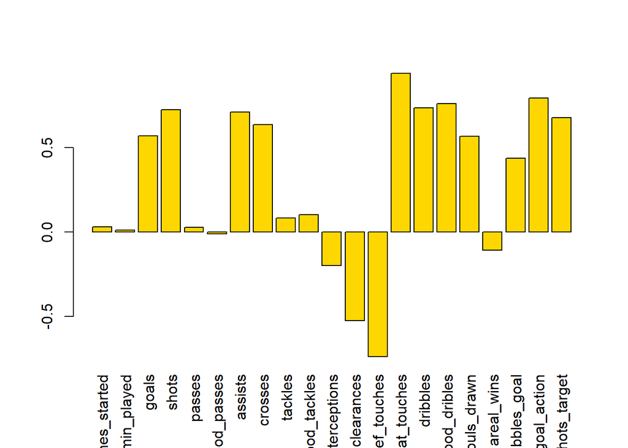

```r
barplot(X_fa_an$loadings[,1], las=3, col="gold")
```

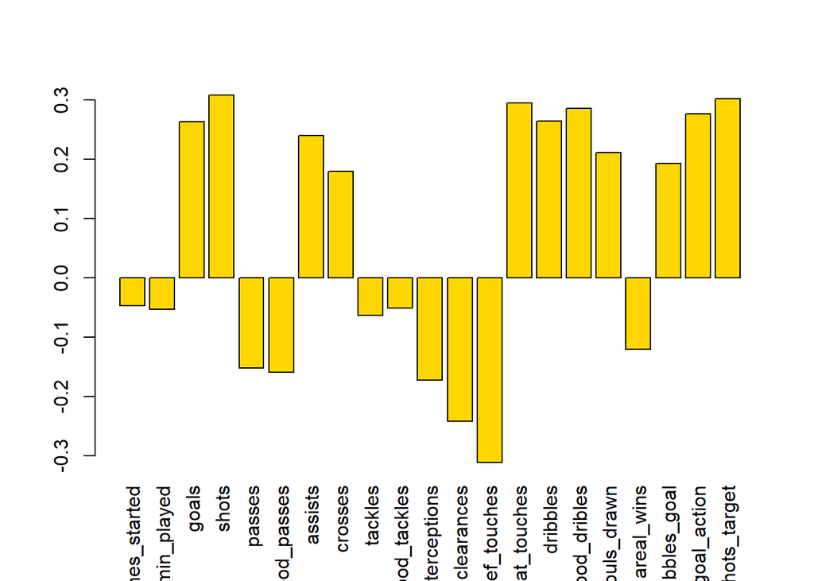

```r
barplot(-pca$rotation[,1], las=3, col="gold")
```

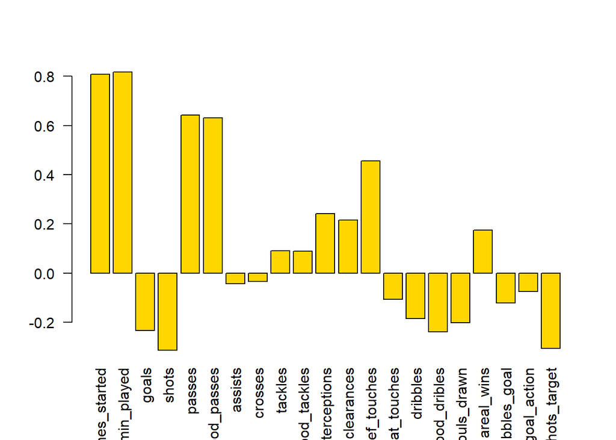

```r
barplot(X_fa_an$loadings[,3], las=2, col="gold")
```

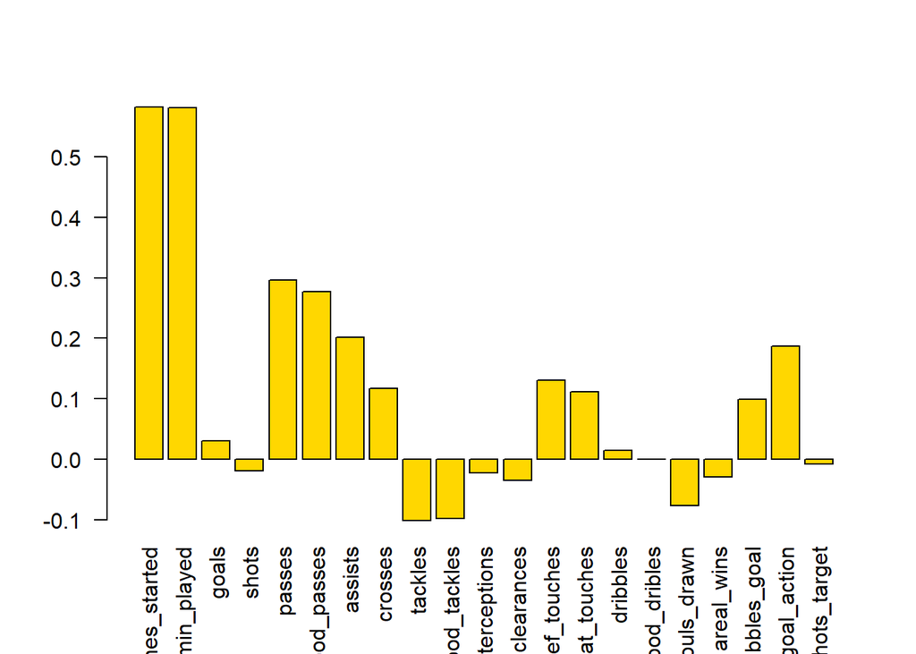

```r
barplot(pca$rotation[,3], las=2, col="gold")
```

PC2 is very broad and general, however Factor 2 emphasis a lot the passing and negatively emphasis playing a lot. This would describe someone who does not play often but is still efficient and useful for the team. This might be the middlefield players.

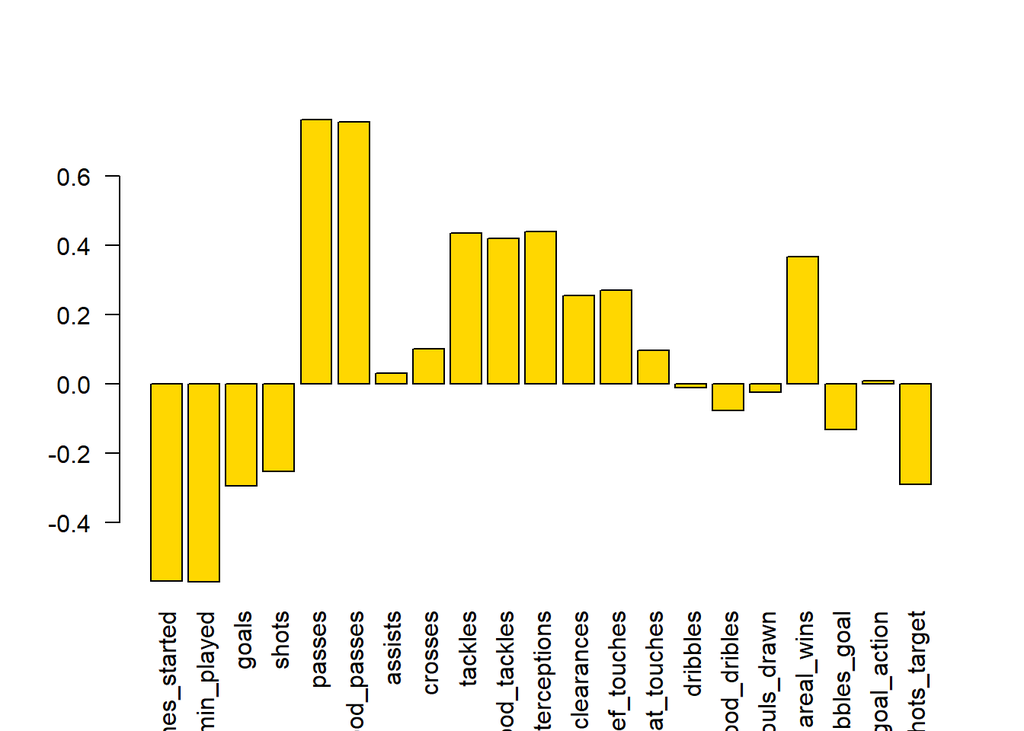

```r
barplot(X_fa_an$loadings[,2], las=2, col="gold")
```

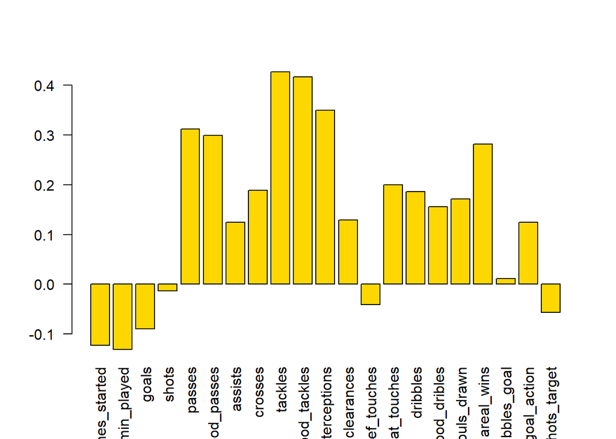

```r
barplot(-pca$rotation[,2], las=2, col="gold")
```

## 2 Factors

```r
X_fa_an <- factanal(X, factors = 2, rotation="none", scores="regression",scale = T)
```

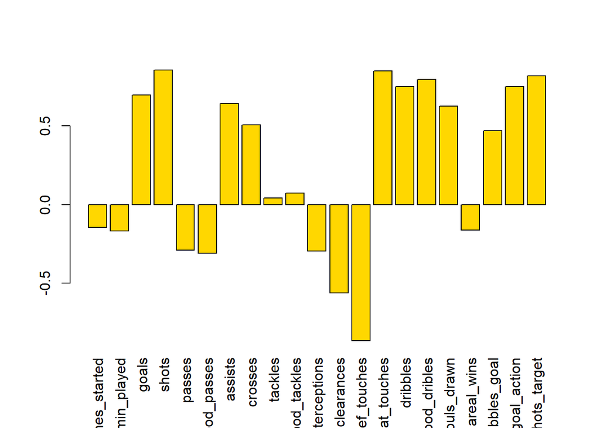

```r
barplot(X_fa_an$loadings[,1], las=3, col="gold")
```

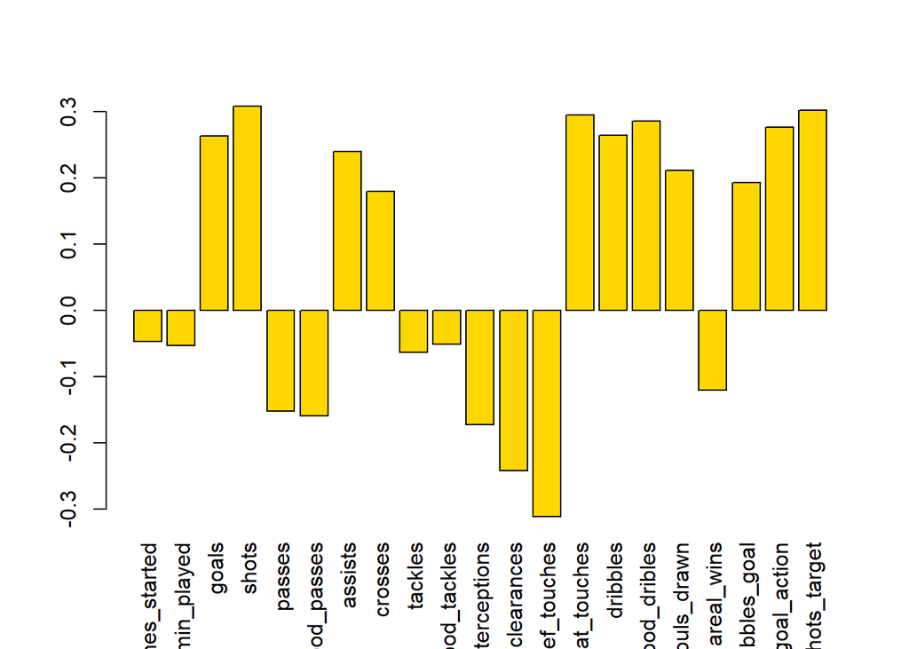

```r
barplot(-pca$rotation[,1], las=3, col="gold")
```

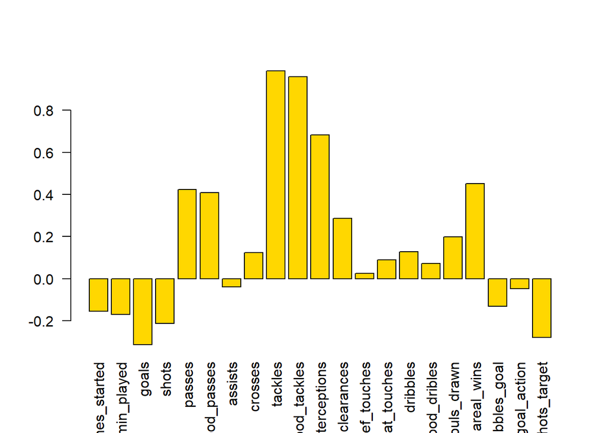

```r
barplot(X_fa_an$loadings[,2], las=2, col="gold")
```

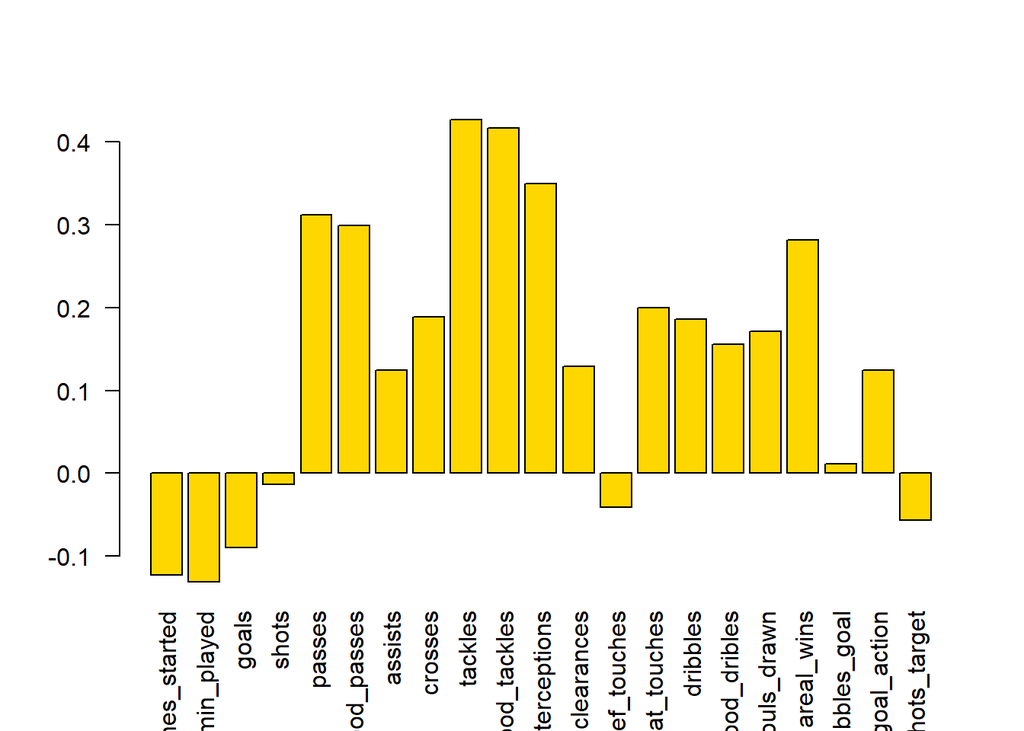

```r
barplot(-pca$rotation[,2], las=2, col="gold")
```

With 4 factors and 2 factors we can guess the position of players like we do with the PCA, start by rating the offensiveness of the player with factor 1 and then evaluate if the player has middle fielder skills else his will be a goalkeeper.

# Clusters

## k -means

### K - means 4 centers

Let’s start the clusters with the k-means, we’re going to use 4 clusters initially for the 4 positions and see what happens. The football teams have many players for each position but have more middle field players, less goalkeeper and a similar amount of defensive and offensive players even though they tend to have more offensive players than defensive players. We can take a look at the groups of players in the clusters and deduce which position is described using that logic.

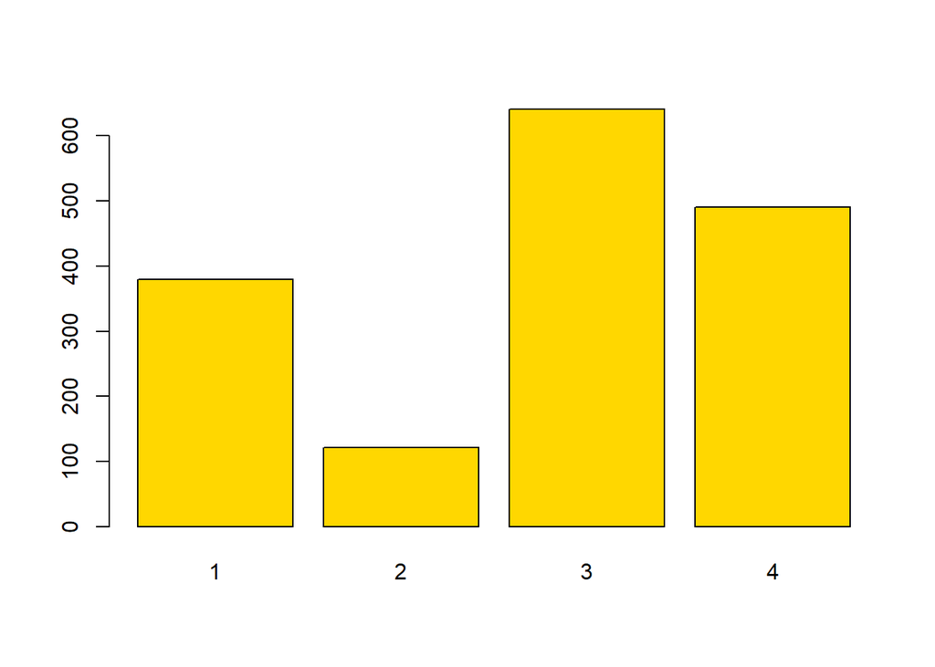

```r
fit.4 = kmeans(X, centers=4, nstart=100)
groups.4 = fit.4$cluster
par(mfrow=c(1,1))

barplot(table(groups.4), col="gold")
```

Once center gives importance to defensive variables like interception, clearance and areal wins. Another de-emphasis all variables except the game played and the defensive touches, this is clearly a description of goalkeepers. A third one gives an emphasis to basically all the variables, especially passes tackles and assists (compared to the mean) this correspond to mid-fielders or generally useful players for the team. Finally for the last one all the offensives’ qualities are highlighted goals, shot, dribbles…

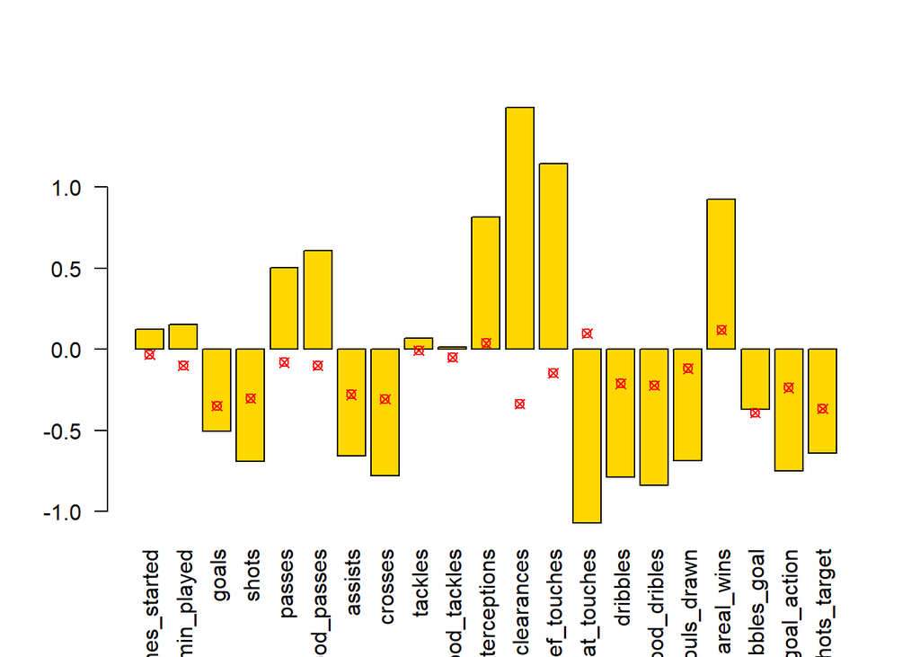

```r
centers4=fit.4$centers
# Center 1 :
bar1=barplot(centers4[1,], las=2, col="gold")
points(bar1,y=apply(X, 2, quantile, 0.50),col="red",pch=13)
```

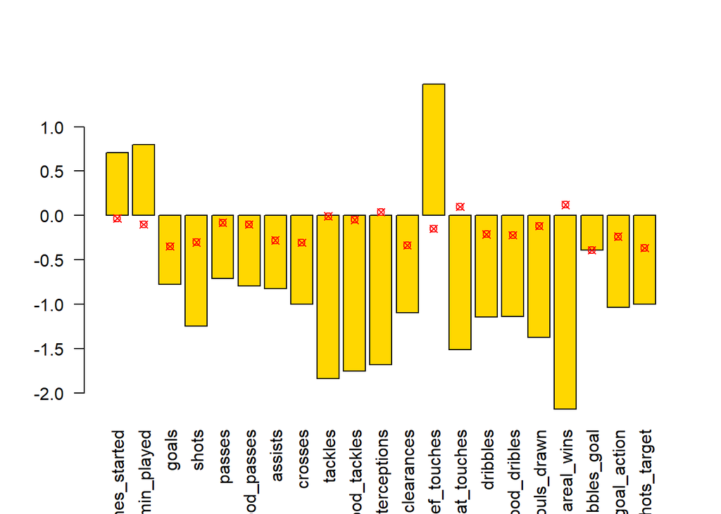

```r
  # Center 2 :
bar1=barplot(centers4[2,], las=2, col="gold",)
points(bar1,y=apply(X, 2, quantile, 0.50),col="red",pch=13)
```